# Sensitivities, elasticities, and management applications

Debora

2023-02-10

## 0.1 Sensitivities, elasticities, and management applications

Remember how populations which achieved a stable stage distribution (SSD) maintain a constant proportion of organisms in each stage? Each of these stages contributes differentially to the overall population, which is indicated by specific reproductive values. Thus, we can expect that vital rates for a stage with more individuals and/or larger reproductive values will have a greater impact to $\lambda$ growth rates. **Sensitivity and elasticity analyses** are performed to determine the importance of each vital rate (survival or reproduction) within stages to the growth of a given population. While **sensitivities** represent absolute differences, **elasticities** enable a proportional comparison between vital rates. The theory and mathematical notations used in this section are based on Mills (2012).

### 0.1.1 Why are sensivities and elasticities important to population ecology studies?

By identifying the most important vital rates to population dynamics, the analysis of sensitivities and elasticities has the potential to guide management decisions in terms of targeting actions to specific life stages. It enables life history comparisons, managing extinction risk, and population growth control (Manlik, Lacy, & Sherwin, 2018). Such analyses are also useful for understanding how a given societal, environmental, or policy change will affect wildlife, and how population fitness evolves as a response to phenotypic changes (Caswell & Caswell, 2019).

### 0.1.2 Sensitivity

How sensitive is population growth to small changes in different vital rates? We can investigate this by looking at how $\lambda$ is impacted (or how sensitive it is) following a very small change in a vital rate within a given population matrix, considering that all of the other matrix elements remain unchanged. This is called analytical sensitivity, which is represented by the following mathematic formulation:

$$a_{i,j} =
\frac{\partial\lambda}{\partial a_{i,j}} =
\frac{v_{i}*w_{j}}{\sum_{k=1}{(v_k*w_k)}}$$
Where: a(i,j) = a given matrix element
$\partial$ = partial derivative denoting a very small change applied to rates while all other variables are held constant
$\lambda$ = rate of population change
v(i) = reproductive value
w(j) = stable stage distribution (SSD) value
v(k) = reproductive value for the last stage class
w(k) = stable stage distribution (SSD) value for the last stage class

### 0.1.3 From sensitivity to elasticity

Because the sensitivity analysis is based in absolute values, changes applied to small values have a disproportional effect in comparison to changes to larger values, which can make comparisons problematic. This is especially true because fecundity rates are usually measured using different units than survival rates. A solution is considering vital rate sizes and making sensitivities proportional to them. Such rescaled sensitivites are then called **elasticities** and can be represented by:

$$\text{Elasticity of }a_{i,j} =
\text{(sensitivity of }a_{i,j})*\frac{a_{i,j}}{\lambda}$$

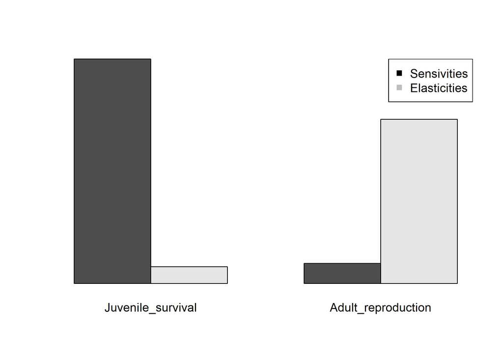

In this plot, you can see how hypothetical absolute sensitivity values change when scaled into elasticities. Matrix elements which are very sensitive (eg., juvenile survival in our plot) greatly alter $\lambda$ rates. But to compare vital rates, we need elasticities. Our elasticities tell us that adult reproduction is proportionally the most significant in terms of impacting growth rates. Thus, a very sensitive element may end up having a low relative elasticity value. In this case, we could recommend to wildlife managers looking at an endangered species to focus on adult reproduction first.

### 0.1.4 Component sensitivity and elasticity

This type of analysis is applicable for the following situations:

- When both survival and reproduction rates affect a given matrix element
- When a certain vital rate impacts more than one matrix element

Component sensitivities and elasticities can be obtained by changing the $\lambda$ SSD by a small amount (eg., 0.01 in the equation below), obtaining the resulting matrix, and obtaining the new $\lambda$ SSD for this changed matrix. Then, you proceed with this calculation for a given vital rate x:

$$x =
\frac{\lambda_{x+0.01}-\lambda_{original}}{0.01}$$

And for the elasticity:

$$\text{Component elasticity of vital rate
x} = \text{(component sensitivity of vital rate x)
}*\frac{x}{\lambda_{original}}$$